# Random Forests and Boosting

Christoph Kern

2 Feb 2018

## Setup

```r
library(foreach)
library(caret)
library(rpart)
library(randomForest)
library(xgboost)
library(pdp)
library(PRROC)
```

## Data

Here we use data from the UCI Machine Learning repository on drug consumption. The data contains records for 1885 respondents with personality measurements (e.g. Big-5), level of education, age, gender, country of residence and ethnicity as features. In addition, information on the usage of 18 drugs is included.

Source: https://archive.ics.uci.edu/ml/datasets/Drug+consumption+%28quantified%29

```r
drugs <- read.csv("drug_consumption.data", header = FALSE)
names(drugs) <- c("ID", "Age", "Gender", "Education", "Country", "Ethnicity", "Neuroticism", "Extraversion", "Openness", "Agreeableness", "Conscientiousness", "Impulsive", "SS", "Alcohol", "Amphet", "Amyl", "Benzos", "Caff", "Cannabis", "Choc", "Coke", "Crack", "Ecstasy", "Heroin", "Ketamine", "Legalh", "LSD", "Meth", "Mushrooms", "Nicotine", "Semer", "VSA")
drugs$Age <- as.factor(drugs$Age)
drugs$Gender  <- as.factor(drugs$Gender)
drugs$Education  <- as.factor(drugs$Education)
drugs$Country <- as.factor(drugs$Country)
drugs$Ethnicity <- as.factor(drugs$Ethnicity)
head(drugs)
```

```
##   ID      Age   Gender Education Country Ethnicity Neuroticism
## 1  1  0.49788  0.48246  -0.05921 0.96082     0.126     0.31287
## 2  2 -0.07854 -0.48246   1.98437 0.96082  -0.31685    -0.67825
## 3  3  0.49788 -0.48246  -0.05921 0.96082  -0.31685    -0.46725
## 4  4 -0.95197  0.48246   1.16365 0.96082  -0.31685    -0.14882
## 5  5  0.49788  0.48246   1.98437 0.96082  -0.31685     0.73545
## 6  6  2.59171  0.48246  -1.22751 0.24923  -0.31685    -0.67825
##   Extraversion Openness Agreeableness Conscientiousness Impulsive       SS
## 1     -0.57545 -0.58331      -0.91699          -0.00665  -0.21712 -1.18084
## 2      1.93886  1.43533       0.76096          -0.14277  -0.71126 -0.21575
## 3      0.80523 -0.84732      -1.62090          -1.01450  -1.37983  0.40148
## 4     -0.80615 -0.01928       0.59042           0.58489  -1.37983 -1.18084
## 5     -1.63340 -0.45174      -0.30172           1.30612  -0.21712 -0.21575
## 6     -0.30033 -1.55521       2.03972           1.63088  -1.37983 -1.54858
##   Alcohol Amphet Amyl Benzos Caff Cannabis Choc Coke Crack Ecstasy Heroin
## 1     CL5    CL2  CL0    CL2  CL6      CL0  CL5  CL0   CL0     CL0    CL0
## 2     CL5    CL2  CL2    CL0  CL6      CL4  CL6  CL3   CL0     CL4    CL0
## 3     CL6    CL0  CL0    CL0  CL6      CL3  CL4  CL0   CL0     CL0    CL0
## 4     CL4    CL0  CL0    CL3  CL5      CL2  CL4  CL2   CL0     CL0    CL0
## 5     CL4    CL1  CL1    CL0  CL6      CL3  CL6  CL0   CL0     CL1    CL0
## 6     CL2    CL0  CL0    CL0  CL6      CL0  CL4  CL0   CL0     CL0    CL0
##   Ketamine Legalh LSD Meth Mushrooms Nicotine Semer VSA
## 1      CL0    CL0 CL0  CL0       CL0      CL2   CL0 CL0
## 2      CL2    CL0 CL2  CL3       CL0      CL4   CL0 CL0
## 3      CL0    CL0 CL0  CL0       CL1      CL0   CL0 CL0
## 4      CL2    CL0 CL0  CL0       CL0      CL2   CL0 CL0
## 5      CL0    CL1 CL0  CL0       CL2      CL2   CL0 CL0
## 6      CL0    CL0 CL0  CL0       CL0      CL6   CL0 CL0
```

For this notebook, we build a dummy variable on LSD usage as our outcome of interest.

```r
drugs$D_LSD <- "LSD"
drugs$D_LSD[drugs$LSD == "CL0"] <- "no LSD"
drugs$D_LSD <- as.factor(drugs$D_LSD)
drugs$D_LSD <- relevel(drugs$D_LSD, "no LSD")
table(drugs$LSD, drugs$D_LSD)
```

```
##
##       no LSD  LSD
##   CL0   1069    0
##   CL1      0  259
##   CL2      0  177
##   CL3      0  214
##   CL4      0   97
##   CL5      0   56
##   CL6      0   13
```

```r
summary(drugs$D_LSD)
```

```
## no LSD    LSD
##   1069    816
```

Then we split the data into a training and a test part. This time we use `createDataPartition` from `caret`, which samples within the levels of the outcome variable when splitting the data.

```r
set.seed(456)
inTrain <- createDataPartition(drugs$D_LSD,
                               p = .8,
                               list = FALSE,
                               times = 1)

drugs_train <- drugs[inTrain,]
drugs_test <- drugs[-inTrain,]
```

## ML models

### Random Forest

In this notebook we use the `caret` package for building prediction models, which offers a lot of useful functions. For this, we first specify our evaluation method. In the following, we use 5-Fold Cross-Validation.

```r
ctrl  <- trainControl(method = "cv",
                      number = 5)
```

Next, a grid object can be used to specify a set of try-out values for tuning. For random forest, we primarily have to care about `mtry`, i.e. the number of features to sample at each split point.

```r
grid <- expand.grid(mtry = c(2,4,6))
```

Both objects can be passed on to `train`, along with the specification of the model and the method. For Random Forest, we use `rf`.

```r
set.seed(744)
rf <- train(D_LSD ~ Age + Gender + Education + Neuroticism + Extraversion +
             Openness + Agreeableness + Conscientiousness + Impulsive + SS,
            data = drugs_train,
            method = "rf",
            trControl = ctrl,
            tuneGrid = grid,
            metric = "Kappa",
            importance = TRUE)
```

Now calling the random forest object lists the results of the tuning process.

```r
rf
```

```
## Random Forest
##
## 1509 samples
##   10 predictor
##    2 classes: 'no LSD', 'LSD'
##
## No pre-processing
## Resampling: Cross-Validated (5 fold)
## Summary of sample sizes: 1207, 1207, 1208, 1207, 1207
## Resampling results across tuning parameters:
##
##   mtry  Accuracy   Kappa
##   2     0.7084069  0.4022737
##   4     0.6991397  0.3860671
##   6     0.7051000  0.3977577
##
## Kappa was used to select the optimal model using  the largest value.
## The final value used for the model was mtry = 2.
```

Plotting the final model gives us an idea of how the error evolves as more trees are added.

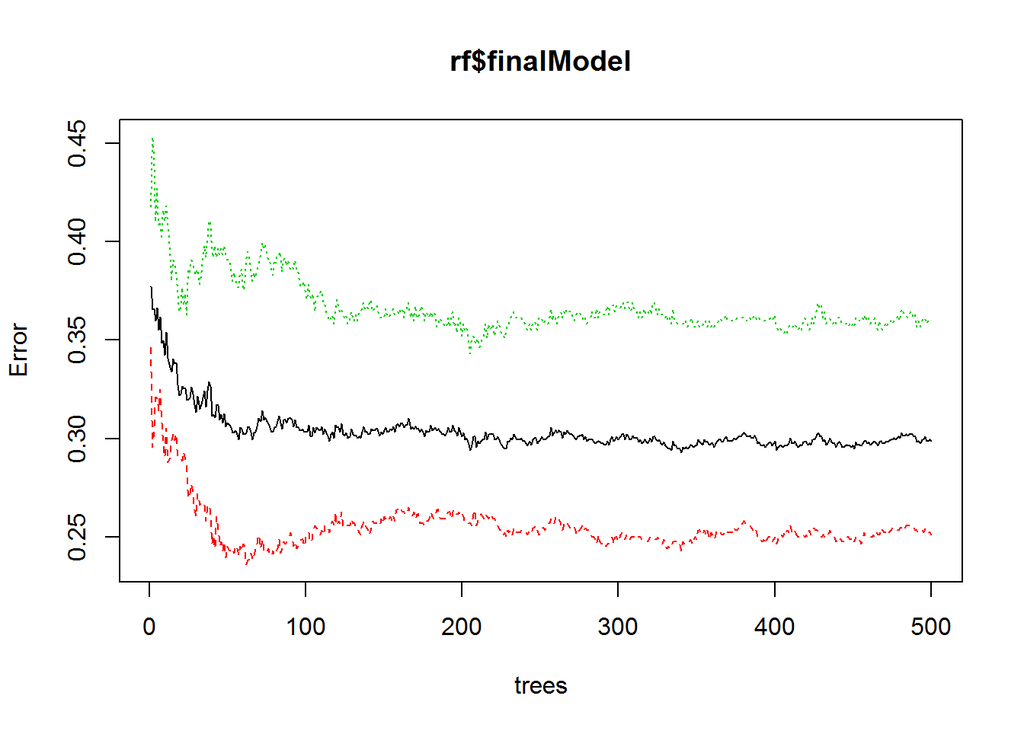

```r
plot(rf$finalModel)
```

With random forests, the individual trees of the ensemble typically look quite different. To get an idea of the components of the forest, `getTree` can be used to list individual trees.

```r
getTree(rf$finalModel, k = 1, labelVar = T)[1:10,]
```

```
##    left daughter right daughter         split var split point status
## 1              2              3      Extraversion   -1.019930      1
## 2              4              5 Education-0.05921    0.500000      1
## 3              6              7        Age2.59171    0.500000      1
## 4              8              9       Neuroticism   -0.297240      1
## 5             10             11        Age1.82213    0.500000      1
## 6             12             13 Education-0.61113    0.500000      1
## 7              0              0              <NA>    0.000000     -1
## 8             14             15          Openness    0.061075      1
## 9             16             17  Education-1.7379    0.500000      1
## 10             0              0              <NA>    0.000000     -1
##    prediction
## 1        <NA>
## 2        <NA>
## 3        <NA>
## 4        <NA>
## 5        <NA>
## 6        <NA>
## 7      no LSD
## 8        <NA>
## 9        <NA>
## 10        LSD
```

```r
getTree(rf$finalModel, k = 2, labelVar = T)[1:10,]
```

```
##    left daughter right daughter         split var split point status
## 1              2              3       Neuroticism    0.364770      1
## 2              4              5     Gender0.48246    0.500000      1
## 3              6              7                SS   -0.067940      1
## 4              8              9       Neuroticism   -1.621205      1
## 5             10             11 Education-1.22751    0.500000      1
## 6             12             13        Age0.49788    0.500000      1
## 7             14             15        Age1.09449    0.500000      1
## 8             16             17                SS   -0.067940      1
## 9             18             19 Education-0.61113    0.500000      1
## 10            20             21          Openness    0.514580      1
##    prediction
## 1        <NA>
## 2        <NA>
## 3        <NA>
## 4        <NA>
## 5        <NA>
## 6        <NA>
## 7        <NA>
## 8        <NA>
## 9        <NA>
## 10       <NA>
```

Calculating variable importance helps us interpreting results from ensemble methods since now we have grown a lot of trees.

```r
varImp(rf)
```

```
## rf variable importance
##
##   only 20 most important variables shown (out of 21)
##
##                   Importance
## Openness             100.000
## SS                    81.039
## Gender0.48246         59.092
## Impulsive             43.485
## Conscientiousness     34.448
## Education1.16365      34.437
## Education-0.61113     33.967
## Age2.59171            33.249
## Extraversion          21.589
## Agreeableness         20.286
## Neuroticism           18.236
## Education-1.7379      17.675
## Education-1.22751     13.442
## Age1.09449            12.886
## Age-0.07854           10.113
## Education1.98437       9.338
## Education0.45468       9.180
## Education-0.05921      8.421
## Education-1.43719      6.976
## Age1.82213             6.013
```

Especially for ensemble methods, plots can be useful in order to see how the features are related to the outcome according to the fitted model. This can be done separately by predictor…

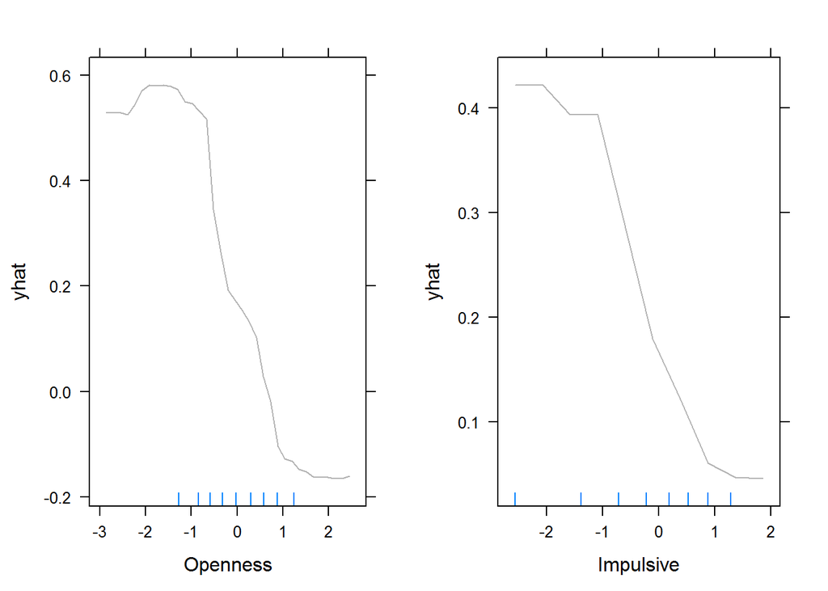

```r
pdp1 <- partial(rf, pred.var = "Openness", trim.outliers = T)
pdp2 <- partial(rf, pred.var = "Impulsive", trim.outliers = T)
p1 <- plotPartial(pdp1, rug = T, train = drugs_train, alpha = 0.3)
p2 <- plotPartial(pdp2, rug = T, train = drugs_train, alpha = 0.3)
grid.arrange(p1, p2, ncol = 2)
```

…and also by considering multiple predictors jointly.

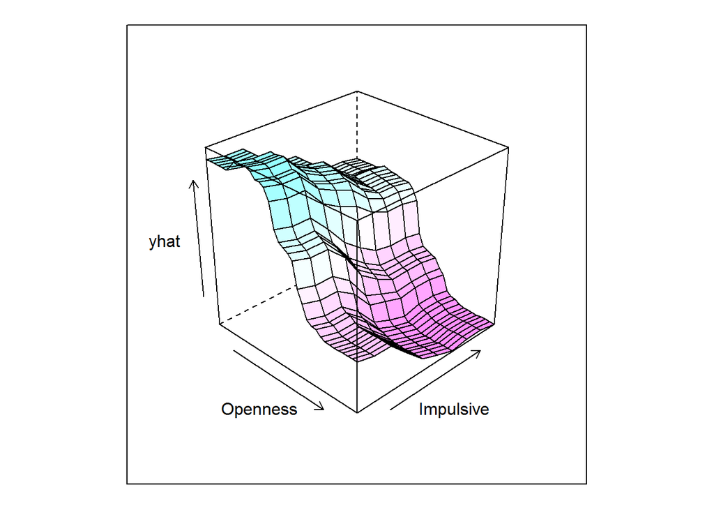

```r
pdp3 <- partial(rf, pred.var = c("Openness", "Impulsive"))
plotPartial(pdp3, levelplot = F, drape = T, colorkey = F, screen = list(z = -45, x = -60))
```

### Boosting

For Gradient Boosting, we have to take care of a couple of tuning parameters. Here, we use `xgboost` and build a grid with all combinations of a set of try-out values. See `?xgboost` for information on the available tuning parameters.

```r
grid <- expand.grid(max_depth = c(1, 3, 5),
                    nrounds = c(500, 1000),
                    eta = c(0.05, 0.01),
                    min_child_weight = 5,
                    subsample = 0.7,
                    gamma = 0,
                    colsample_bytree = 1)
grid
```

```
##    max_depth nrounds  eta min_child_weight subsample gamma
## 1          1     500 0.05                5       0.7     0
## 2          3     500 0.05                5       0.7     0
## 3          5     500 0.05                5       0.7     0
## 4          1    1000 0.05                5       0.7     0
## 5          3    1000 0.05                5       0.7     0
## 6          5    1000 0.05                5       0.7     0
## 7          1     500 0.01                5       0.7     0
## 8          3     500 0.01                5       0.7     0
## 9          5     500 0.01                5       0.7     0
## 10         1    1000 0.01                5       0.7     0
## 11         3    1000 0.01                5       0.7     0
## 12         5    1000 0.01                5       0.7     0
##    colsample_bytree
## 1                 1
## 2                 1
## 3                 1
## 4                 1
## 5                 1
## 6                 1
## 7                 1
## 8                 1
## 9                 1
## 10                1
## 11                1
## 12                1
```

Again, this is passed on to `train`, now using `xgbTree` instead of `rf`.

```r
set.seed(744)
xgb <- train(D_LSD ~ Age + Gender + Education + Neuroticism + Extraversion +
             Openness + Agreeableness + Conscientiousness + Impulsive + SS,
             data = drugs_train,
             method = "xgbTree",
             trControl = ctrl,
             tuneGrid = grid,
             metric = "Kappa")
```

Instead of just printing the results from the tuning process, we can also plot them.

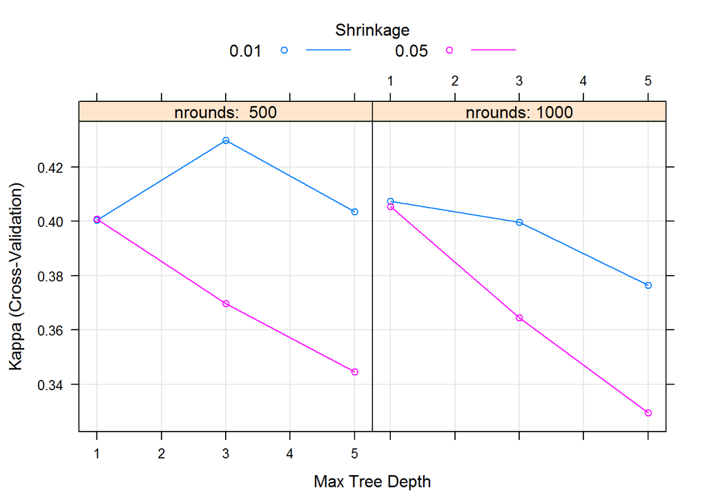

```r
plot(xgb)
```

### CART

Adding a single tree for comparison…

```r
set.seed(744)
cart <- train(D_LSD ~ Age + Gender + Education + Neuroticism + Extraversion +
             Openness + Agreeableness + Conscientiousness + Impulsive + SS,
              data = drugs_train,
              method = "rpart2",
              trControl = ctrl,
              metric = "Kappa")
cart
```

```
## CART
##
## 1509 samples
##   10 predictor
##    2 classes: 'no LSD', 'LSD'
##
## No pre-processing
## Resampling: Cross-Validated (5 fold)
## Summary of sample sizes: 1207, 1207, 1208, 1207, 1207
## Resampling results across tuning parameters:
##
##   maxdepth  Accuracy   Kappa
##   1         0.6607093  0.3251992
##   2         0.6865460  0.3573622
##   5         0.6997910  0.3803416
##
## Kappa was used to select the optimal model using  the largest value.
## The final value used for the model was maxdepth = 5.
```

### Logistic regression

…and also a logistic regression model.

```r
set.seed(744)
logit <- train(D_LSD ~ Age + Gender + Education + Neuroticism + Extraversion +
             Openness + Agreeableness + Conscientiousness + Impulsive + SS,
             data = drugs_train,
             method = "glm",
             trControl = ctrl)
```

We may want to take a glimpse at the regression results.

```r
summary(logit)
```

```
##
## Call:
## NULL
##
## Deviance Residuals:
##     Min       1Q   Median       3Q      Max
## -2.5837  -0.8702  -0.4169   0.9361   2.6533
##
## Coefficients:
##                      Estimate Std. Error z value Pr(>|z|)
## (Intercept)           0.40060    0.54351   0.737 0.461084
## `Age-0.07854`         0.38544    0.17336   2.223 0.026193 *
## Age0.49788            0.73379    0.19369   3.789 0.000152 ***
## Age1.09449            0.66220    0.20322   3.258 0.001120 **
## Age1.82213            0.31115    0.30034   1.036 0.300208
## Age2.59171          -13.74513  362.86402  -0.038 0.969784
## Gender0.48246        -0.69061    0.12964  -5.327 9.98e-08 ***
## `Education-1.7379`   -0.84385    0.59390  -1.421 0.155355
## `Education-1.43719`  -0.23593    0.71350  -0.331 0.740893
## `Education-1.22751`  -0.35098    0.59345  -0.591 0.554239
## `Education-0.61113`  -0.44425    0.54845  -0.810 0.417929
## `Education-0.05921`  -0.92680    0.56102  -1.652 0.098534 .
## Education0.45468     -0.85897    0.54822  -1.567 0.117149
## Education1.16365     -1.29084    0.56183  -2.298 0.021587 *
## Education1.98437     -1.02394    0.61166  -1.674 0.094123 .
## Neuroticism          -0.04858    0.07381  -0.658 0.510439
## Extraversion         -0.33807    0.07510  -4.502 6.74e-06 ***
## Openness              0.73404    0.07583   9.680  < 2e-16 ***
## Agreeableness        -0.10816    0.06586  -1.642 0.100512
## Conscientiousness    -0.06966    0.07376  -0.944 0.344956
## Impulsive             0.10713    0.08505   1.260 0.207796
## SS                    0.55982    0.09250   6.052 1.43e-09 ***
## ---
## Signif. codes:  0 '***' 0.001 '**' 0.01 '*' 0.05 '.' 0.1 ' ' 1
##
## (Dispersion parameter for binomial family taken to be 1)
##
##     Null deviance: 2064.5  on 1508  degrees of freedom
## Residual deviance: 1639.3  on 1487  degrees of freedom
## AIC: 1683.3
##
## Number of Fisher Scoring iterations: 14
```

## Comparison

After we ran a bunch of models, we can use `resamples` to gather the cross-validation results from all of them.

```r
resamps <- resamples(list(RandomForest = rf,
                          Boosting = xgb,
                          CART = cart,
                          Logit = logit))
```

This object can now be used for comparing these models with respect to their performance, based on CV in the training set.

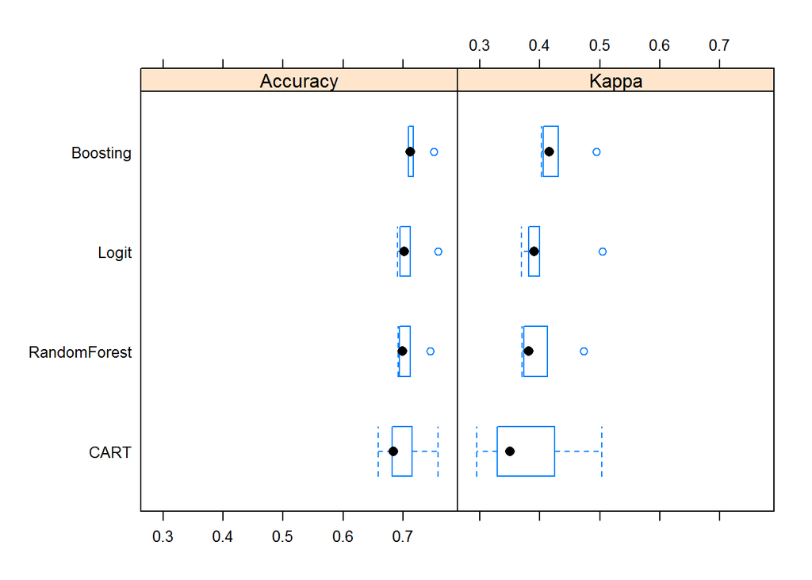

```r
bwplot(resamps)
```

## Prediction

For evaluating performance, we predict the outcome in the test set in two formats. We can use `predict` for predicting class membership (here for all methods) and also for computing predicted probabilities (here for the xgboost result).

```r
p_rf1 <- predict(rf, newdata = drugs_test)
p_xgb1 <- predict(xgb, newdata = drugs_test)
p_cart1 <- predict(cart, newdata = drugs_test)
p_logit1 <- predict(logit, newdata = drugs_test)

p_xgb2 <- predict(xgb, newdata = drugs_test, type = "prob")
```

Given predicted class membership, we can use the function `confusionMatrix` for evaluating our classification models.

```r
confusionMatrix(p_rf1, drugs_test$D_LSD)
```

```
## Confusion Matrix and Statistics
##
##           Reference
## Prediction no LSD LSD
##     no LSD    148  58
##     LSD        65 105
##
##                Accuracy : 0.6729
##                  95% CI : (0.6229, 0.7201)
##     No Information Rate : 0.5665
##     P-Value [Acc > NIR] : 1.564e-05
##
##                   Kappa : 0.3373
##  Mcnemar's Test P-Value : 0.5885
##
##             Sensitivity : 0.6948
##             Specificity : 0.6442
##          Pos Pred Value : 0.7184
##          Neg Pred Value : 0.6176
##              Prevalence : 0.5665
##          Detection Rate : 0.3936
##    Detection Prevalence : 0.5479
##       Balanced Accuracy : 0.6695
##
##        'Positive' Class : no LSD
##
```

```r
confusionMatrix(p_xgb1, drugs_test$D_LSD)
```

```
## Confusion Matrix and Statistics
##
##           Reference
## Prediction no LSD LSD
##     no LSD    151  61
##     LSD        62 102
##
##                Accuracy : 0.6729
##                  95% CI : (0.6229, 0.7201)
##     No Information Rate : 0.5665
##     P-Value [Acc > NIR] : 1.564e-05
##
##                   Kappa : 0.3344
##  Mcnemar's Test P-Value : 1
##
##             Sensitivity : 0.7089
##             Specificity : 0.6258
##          Pos Pred Value : 0.7123
##          Neg Pred Value : 0.6220
##              Prevalence : 0.5665
##          Detection Rate : 0.4016
##    Detection Prevalence : 0.5638
##       Balanced Accuracy : 0.6673
##
##        'Positive' Class : no LSD
##
```

```r
confusionMatrix(p_cart1, drugs_test$D_LSD)
```

```
## Confusion Matrix and Statistics
##
##           Reference
## Prediction no LSD LSD
##     no LSD    154  73
##     LSD        59  90
##
##                Accuracy : 0.6489
##                  95% CI : (0.5983, 0.6972)
##     No Information Rate : 0.5665
##     P-Value [Acc > NIR] : 0.0006821
##
##                   Kappa : 0.278
##  Mcnemar's Test P-Value : 0.2578427
##
##             Sensitivity : 0.7230
##             Specificity : 0.5521
##          Pos Pred Value : 0.6784
##          Neg Pred Value : 0.6040
##              Prevalence : 0.5665
##          Detection Rate : 0.4096
##    Detection Prevalence : 0.6037
##       Balanced Accuracy : 0.6376
##
##        'Positive' Class : no LSD
##
```

```r
confusionMatrix(p_logit1, drugs_test$D_LSD)
```

```
## Confusion Matrix and Statistics
##
##           Reference
## Prediction no LSD LSD
##     no LSD    158  64
##     LSD        55  99
##
##                Accuracy : 0.6835
##                  95% CI : (0.6339, 0.7302)
##     No Information Rate : 0.5665
##     P-Value [Acc > NIR] : 2.169e-06
##
##                   Kappa : 0.3514
##  Mcnemar's Test P-Value : 0.4633
##
##             Sensitivity : 0.7418
##             Specificity : 0.6074
##          Pos Pred Value : 0.7117
##          Neg Pred Value : 0.6429
##              Prevalence : 0.5665
##          Detection Rate : 0.4202
##    Detection Prevalence : 0.5904
##       Balanced Accuracy : 0.6746
##
##        'Positive' Class : no LSD
##
```

Additionally, ROC curves are helpful for evaluating prediction performance with categorical outcomes. Here we could (e.g.) use the `PRROC` package, which has a function called `roc.curve`.

```r
fg <- p_xgb2[drugs_test$D_LSD == "LSD", 2]
bg <- p_xgb2[drugs_test$D_LSD == "no LSD", 2]
roc <- roc.curve(scores.class0 = fg, scores.class1 = bg, curve = T)
```

Finally, we can print and plot the resulting roc object.

```r
roc
```

```
##
##   ROC curve
##
##     Area under curve:
##      0.7328552
##
##     Curve for scores from  0.03669667  to  0.8787743
##     ( can be plotted with plot(x) )
```

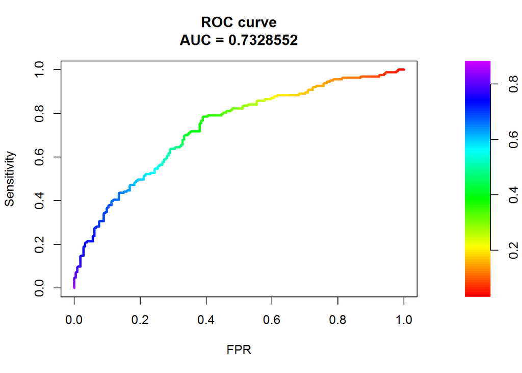

```r
plot(roc)
```

## References

- E. Fehrman, A. K. Muhammad, E. M. Mirkes, V. Egan and A. N. Gorban (2015). The Five Factor Model of personality and evaluation of drug consumption risk. https://arxiv.org/abs/1506.06297.